# Data visualization

Damiano Oldoni

you

2023-11-20

# 1 Setup

Load packages:

```r
library(tidyverse) # to do datascience
library(geepack) # to do modelling
library(INBOtheme) # to apply INBO style to graphs
library(sf) # to work with geospatial vector data
library(leaflet) # to make dynamic maps
library(htmltools) # to make nice html labels for dynamic maps
library(here) # to work with paths
library(DT) # to create highly customizable data tables
library(crosstalk) # to create cross-widget interactions
```

Notice we have to “reload” tidyverse: the knitting process of a RMarkdown is an universe (*environment*) apart!

Same holds true for `catch_fl`, the cleaned data as output of challenge 1. Again, notice that it is present in your *local* environment, but won’t be during the knitting process.

Read `catch_fl` containing the cleaned geese catch data. Notice that this file is not provided, but it’s written on disk in the last section of `1_geese_read_data.Rmd`:

```r
path_catch_file <- here::here("data", "20231026", "20231026_geese_counts_cleaned.txt")
catch_fl <- read_csv(path_catch_file, na = "")
```

# 2 Introduction

In this section we will show how number of catches varies by year, province and species. Both static plots and dynamic maps are generated.

# 3 Static plots

## 3.1 Show catches

### 3.1.1 per province

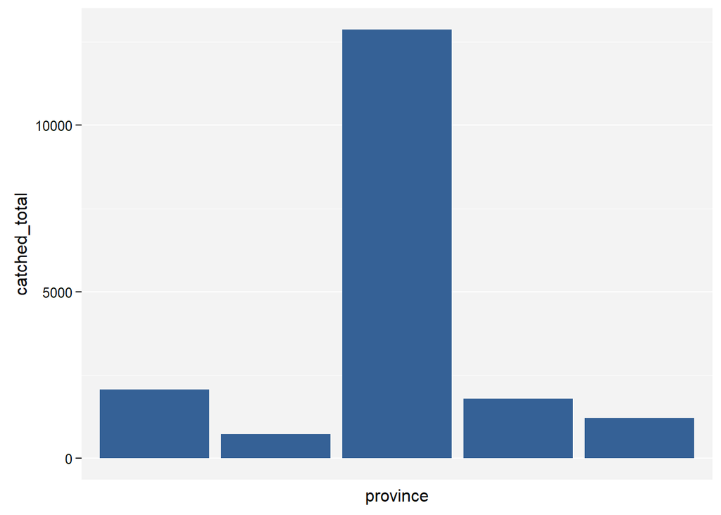

### 3.1.2 per year

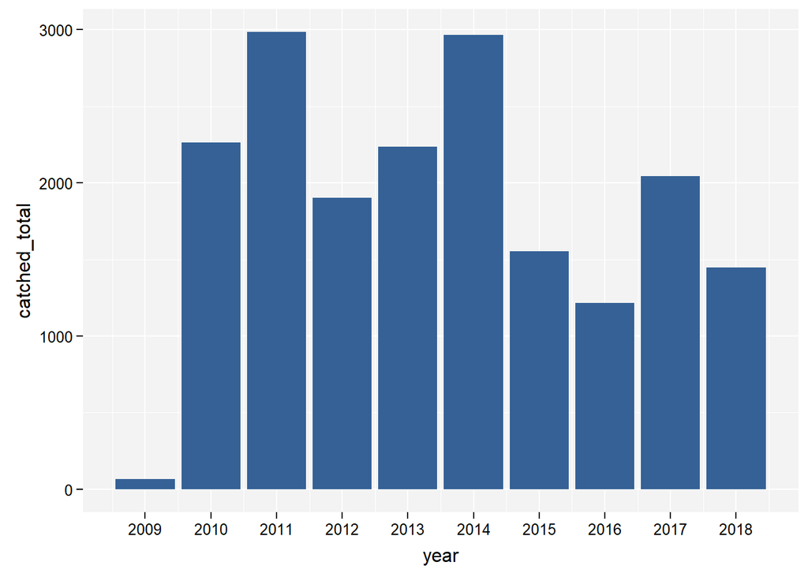

```r
catch_per_year <- catch_fl %>%
  group_by(year) %>%
  summarize(catched_total = sum(catched, na.rm = TRUE)) %>%
  ungroup() %>%
  arrange(desc(catched_total))
ggplot(
  catch_per_year,
  aes(x = year, y = catched_total)
) +
  geom_bar(stat = "identity") +
  scale_x_continuous(breaks = 2009:2018)
```

### 3.1.3 per year and province

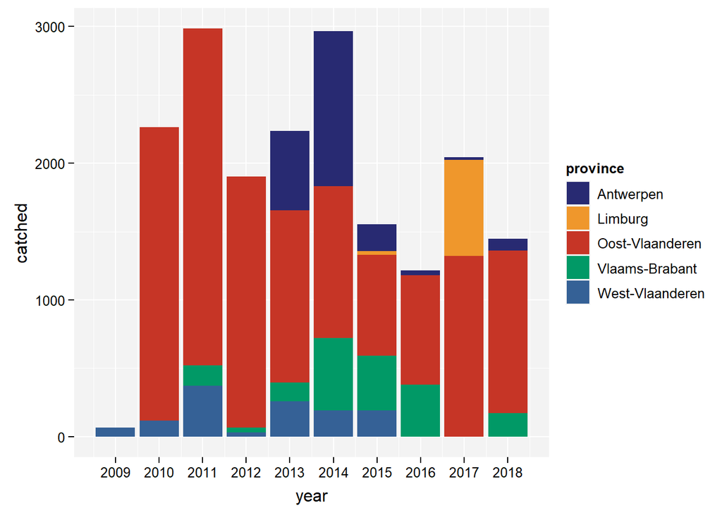

```r
catch_per_year_province <-
  catch_fl %>%
  group_by(year, province) %>%
  summarize(catched = sum(catched, na.rm = TRUE)) %>%
  ungroup() %>%
  arrange(desc(catched))
ggplot(
  catch_per_year_province,
  aes(x = year, y = catched, fill = province)
) +
  geom_bar(stat = "identity") +
  scale_x_continuous(breaks = 2009:2018)
```

## 3.2 Catch analysis at species level

### 3.2.1 Species selection

Before we proceed to analyse the catches at species level, specify the species we are interested to by `commonName`:

```r
species <- c(
  "Brandgans",
  "Canadese gans",
  "Grauwe gans",
  "Soepgans",
  "Nijlgans"
)
```

### 3.2.2 Catches per year and species

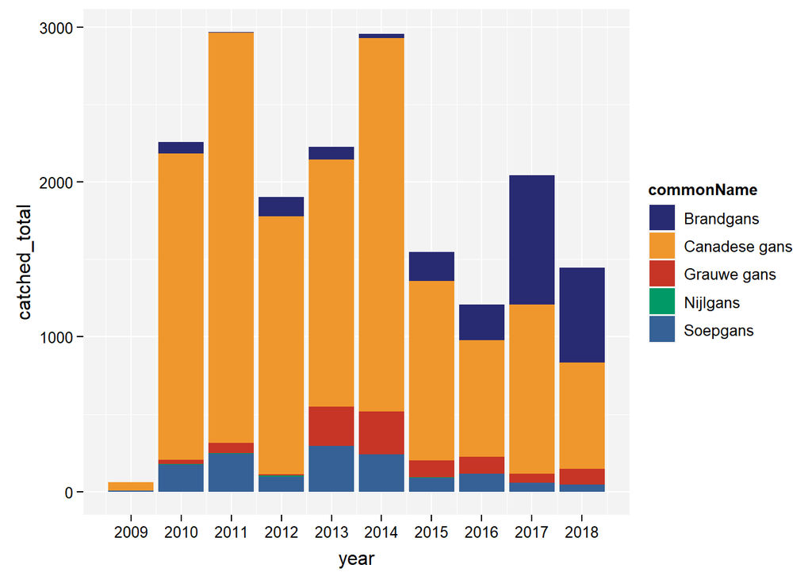

```r
catch_species <-
  catch_fl %>%
  dplyr::filter(commonName %in% species) %>%
  group_by(year, commonName) %>%
  summarize(catched_total = sum(catched, na.rm = TRUE)) %>%
  arrange(commonName)
ggplot(
  catch_species,
  aes(x = year, y = catched_total, fill = commonName)
) +
  geom_bar(stat = "identity") +
  scale_x_continuous(breaks = 2009:2018)
```

### 3.2.3 Data modelling

We apply a GEE (generalized estimating equations) model to data from 2010.

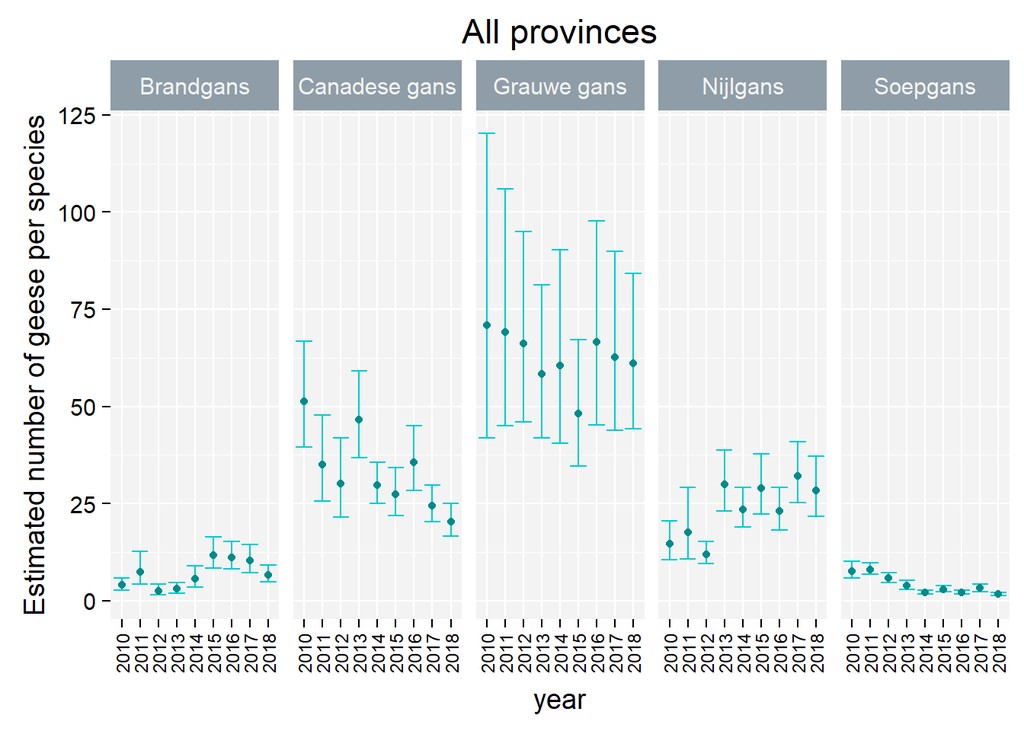

```r
model_per_species <-
  map(
    species,
    function(s) {
      dfs <- catch_fl %>%
        dplyr::filter(commonName == s & year >= 2010) %>%
        arrange(location, year) %>%
        mutate(
          year = as_factor(as.character(year)),
          location = as_factor(location)
        )
      geeglm(counts ~ 0 + year,
        family = poisson,
        data = dfs,
        waves = year,
        id = location
      )
    }
  )
names(model_per_species) <- species
overview_model <- map(model_per_species, ~ summary(.))
overview_gee <- map2_dfr(
  overview_model,
  names(overview_model), function(model, name) {
    coefficients(model)[, 1:2] %>%
      rownames_to_column(var = "year") %>%
      as_tibble() %>%
      mutate(
        species = name,
        year = str_sub(year, start = 5)
      ) %>%
      # added dplyr:: as select() exists in sf package as well.
      # Some people could get an error at this line otherwise.
      dplyr::select(species, everything())
  }
)
overview_gee <-
  overview_gee %>%
  mutate(
    lwr = exp(Estimate - Std.err),
    upr = exp(Estimate + Std.err),
    Estimate = exp(Estimate)
  )
ggplot(
  overview_gee,
  aes(x = year, y = Estimate, ymin = lwr, ymax = upr)
) +
  geom_errorbar(colour = "cyan3") +
  geom_point(colour = "cyan4") +
  facet_grid(. ~ species) +
  xlab("year") +
  ylab("Estimated number of geese per species") +
  theme_inbo(14) +
  theme(axis.text.x = element_text(angle = 90, vjust = 0.5, size = 9)) +
  labs(title = "All provinces")
```

# 4 Dynamic maps

We make dynamic *leaflet* maps of total number of catches per province.

We read the polygons without showing the code (chunk option: `include=FALSE`).

```r
pr_fl <- pr_fl %>%
  dplyr::left_join(catch_per_province,
    by = c("TX_PROV_DESCR_NL" = "province")
  )
bins <- seq(0, 14000, by = 2000)
pal <- colorBin("YlOrRd", domain = pr_fl$catched_total, bins = bins)

labels <- sprintf(
  "<strong>%s</strong><br/>%g catches",
  pr_fl$TX_PROV_DESCR_NL, pr_fl$catched_total
) %>% lapply(HTML)

map_catch_pr <- leaflet(pr_fl) %>%
  addTiles() %>%
  addPolygons(
    fillColor = ~ pal(catched_total),
    weight = 2,
    opacity = 1,
    color = "white",
    dashArray = "3",
    fillOpacity = 0.7,
    highlightOptions = highlightOptions(
      weight = 5,
      color = "#666",
      dashArray = "",
      fillOpacity = 0.7,
      bringToFront = TRUE
    ),
    label = labels,
    labelOptions = labelOptions(
      style = list("font-weight" = "normal", padding = "3px 8px"),
      textsize = "15px",
      direction = "auto"
    )
  )
map_catch_pr
```

[interactive chart not shown]

## 4.1 crosstalk

We show also what you can do using the crosstalk package. For example, you can interactively link the catches data.frame (shown as a HTML table on the right) to a leaflet map. We limit us only to the catches of 2018 of the species used for modelling:

```r
catch_fl_spatial <- catch_fl %>%
  # filter by species and year
  dplyr::filter(commonName %in% species & year == 2018) %>%
  # use x and y columns to convert to spatial data.frame
  st_as_sf(coords = c("x", "y"), crs = 4326)

shared_catch_fl_spatial <- crosstalk::SharedData$new(catch_fl_spatial)

# create map first
map_shared_catch_fl_spatial <- leaflet(shared_catch_fl_spatial) %>%
  addTiles() %>%
  addCircleMarkers(radius = 1)

# create table with the data
data_table <- DT::datatable(
  shared_catch_fl_spatial,
  extensions = "Scroller",
  style = "bootstrap",
  class = "compact",
  width = "100%",
  options = list(deferRender = TRUE, scrollY = 300, scroller = TRUE)
)

# combine map and table together
crosstalk::bscols(map_shared_catch_fl_spatial, data_table)
```

[interactive chart not shown]

|  | province | location | year | latinName | commonName | counts | catched | geometry |
| --- | --- | --- | --- | --- | --- | --- | --- | --- |
| 1 | Antwerpen | Antwerpen | 2018 | Alopochen aegyptiacus | Nijlgans | 12 |  | {'type': 'Point', 'coordinates': [4.39161, 51.1087]} |
| 2 | Antwerpen | Antwerpen | 2018 | Anser anser | Grauwe gans | 2 |  | {'type': 'Point', 'coordinates': [4.14796, 50.78105]} |
| 3 | Antwerpen | Antwerpen | 2018 | Anser anser forma domesticus | Soepgans | 0 |  | {'type': 'Point', 'coordinates': [5.8506, 50.74037]} |
| 4 | Antwerpen | Antwerpen | 2018 | Branta canadensis | Canadese gans | 64 |  | {'type': 'Point', 'coordinates': [3.4415, 50.82618]} |
| 5 | Antwerpen | Antwerpen | 2018 | Branta leucopsis | Brandgans | 0 |  | {'type': 'Point', 'coordinates': [2.99137, 50.92843]} |
| 6 | Antwerpen | Beerse | 2018 | Alopochen aegyptiacus | Nijlgans | 8 |  | {'type': 'Point', 'coordinates': [5.19728, 51.09375]} |
| 7 | Antwerpen | Beerse | 2018 | Anser anser | Grauwe gans | 26 |  | {'type': 'Point', 'coordinates': [4.87836, 50.90303]} |
| 8 | Antwerpen | Beerse | 2018 | Anser anser forma domesticus | Soepgans | 0 |  | {'type': 'Point', 'coordinates': [4.84449, 51.138]} |
| 9 | Antwerpen | Beerse | 2018 | Branta canadensis | Canadese gans | 60 |  | {'type': 'Point', 'coordinates': [4.06983, 51.1736]} |
| 10 | Antwerpen | Beerse | 2018 | Branta leucopsis | Brandgans | 36 |  | {'type': 'Point', 'coordinates': [4.92756, 50.990476]} |

[output cut: 407 more lines]

Some limitations:

1. No polygons, only points at the moment
2. The interaction doesn’t work with adding the clustering option in the leaflet markers, e.g. using `addCircleMarkers(radius = 1, clusterOptions = markerClusterOptions())`
3. Because all data must be loaded into the browser, crosstalk is not appropriate for large data sets.

Do you want more? Go to crosstalk [homepage](https://rstudio.github.io/crosstalk/index.html).